# Exploratory data analysis and Modelization

### 2. New categorical variables:

#### Day-night

We can create a new categorical variable related to the time of the day in which the trip is made. From the ‘hour’ variable we can detect if it is ‘daytime’ or nigth.

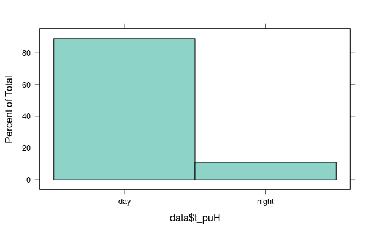

```r
data$t_puH  <-  data$t_pu
data$t_doH  <-  data$t_do
data[which(data[ ,"t_puH"] >= 7 & data[ ,"t_puH"] <= 20), 't_puH']  <- "day"
data[which(data[ ,"t_puH"] != "day"), 't_puH']  <- "night"
data[which(data[ ,"t_doH"] >= 7 & data[ ,"t_doH"] <= 20), 't_doH']  <- "day"
data[which(data[ ,"t_doH"] != "day"), 't_doH']  <- "night"
data$t_puH  <-  as.factor(data$t_puH)
data$t_doH  <-  as.factor(data$t_doH)
histogram(data$t_puH, par.settings=myTheme)
```

Most of the trips are made during the daytime hours. The selection of the hours is kind of arbitrary ,and a different classification of ‘day’ and ‘night’ could be also possible.

#### Weekday

We consider now the day of the week as well as a categorical variable, in order to see if there is a day in which people take more the taxi or if it influences on the fares/tips etc.

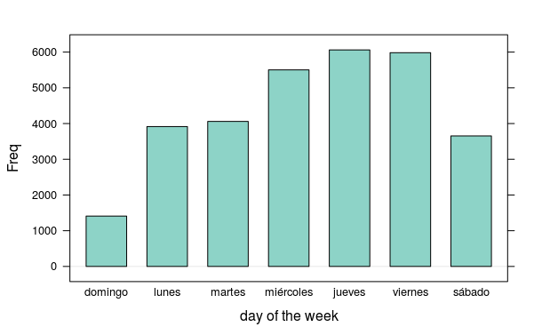

```r
data$weekday <- weekdays(data$tpep_pickup_datetime)
data$weekday <- factor(data$weekday, levels=c("domingo","lunes","martes", "miércoles","jueves","viernes","sábado"))
# plot
barchart(as.factor(data$weekday), par.settings=myTheme, horizontal=FALSE,xlab='day of the week')
```

Although most of the days have similar amount of records, it is clear that Sunday is the day when there are less taxi trips in the New York city.

#### Intra trip

We create another categorical variable related to the intra characteristic of the record. We consider trips that pick up and drop off in a different borough as intratrip. Next graph shows how most of the trip records are made in the same borough.

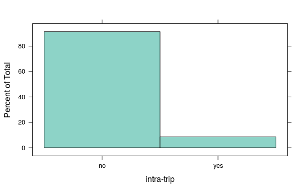

```r
data$intratrip <- seq(1:nrow(data))
data[which(data$PU_boroughzone != data$DO_boroughzone), "intratrip"] <- "yes"
data[which(data$PU_boroughzone == data$DO_boroughzone), "intratrip"] <- "no"
histogram(as.factor(data$intratrip), par.settings=myTheme, xlab='intra-trip')
```

## 4. Numeric variables and categorical variables

### 4.1 boxplot for trip variables

We can represent numeric variables depending on some categorical variables like: the pick up or drop off area or the day of the week.

#### Relationship with the borough:

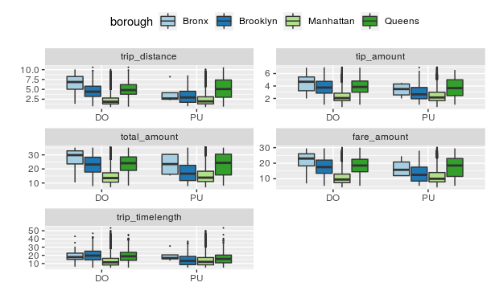

```r
## all together:
tip <- melt(data[,c(14,23,24)], 'tip_amount')
trip  <-  melt(data[,c(5,23,24)], 'trip_distance')
fare  <-  melt(data[,c(11,23,24)], 'fare_amount')
total  <-  melt(data[,c(17,23,24)], 'total_amount')
trip_time  <-  melt(data[,c(18,23,24)], 'trip_timelength')
all  <-  cbind(trip, tip, total, fare,trip_time)
all  <-  all[,c(1,4,7,10,13,14,15)]
b  <-  melt(all)
names(b)  <-  c("pu_do","borough","variable","value")
b$pu_do <- as.character(b$pu_do)
b[(b$pu_do == "PU_boroughzone"), "pu_do"] <- 'PU'
b[(b$pu_do == "DO_boroughzone"), "pu_do"] <- 'DO'
ggplot(b, aes(x=pu_do,y=value)) +
    geom_boxplot(aes(fill=borough),outlier.size = 0.1) + scale_fill_brewer(palette="Paired") +
    labs(x=" ", y=" ") +
     facet_wrap(~ variable, scales='free', ncol=2) + theme(legend.position="top")
```

The above picture shows that the are few differences on the data distribution of each variable regardless of the *pick up* and *drop off area*. Among areas, we see how the borough of Manhattan is the one with lower fare, tip amount, trip distance and trip duration.

#### Relationship with day of the week

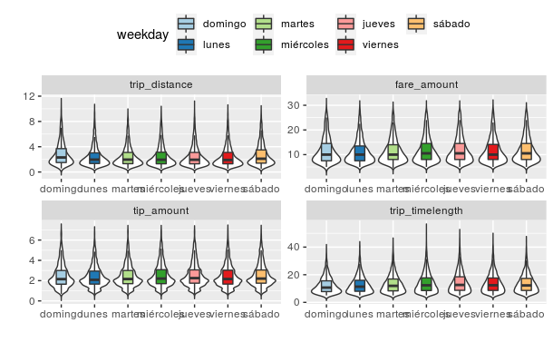

```r
all <- data[,c(5,11,14,18,27)]
all <- melt(all, 'weekday')
ggplot(all, aes(x=weekday,y=value)) +
  geom_violin(trim=FALSE)+
    geom_boxplot(aes(fill=weekday),outlier.size = 0.1, outlier.shape = NA, width=0.3) + scale_fill_brewer(palette="Paired") +
    labs(x=" ", y=" ") +
     facet_wrap(~ variable, scales='free', ncol=2)+ theme(legend.position="top")
```

The figure shows that he sunday is different from the rest of the week, with higher median values from the trip distance. However, the rest of the variables it seems to be higher in the central days of the weeks. Differences are subtle in any case.

#### Showing the intra trip variable

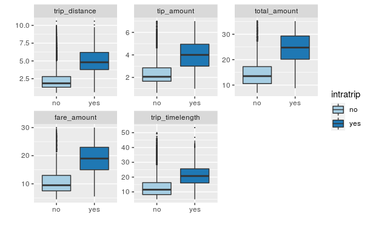

```r
trip  <-  melt(data[,c(5,28)], 'trip_distance')
tip  <-  melt(data[,c(14,28)], 'tip_amount')
fare  <-  melt(data[,c(11,28)], 'fare_amount')
total  <-  melt(data[,c(17,28)], 'total_amount')
trip_time  <-  melt(data[,c(18,28)], 'trip_timelength')
all  <-  cbind(trip, tip, total, fare, trip_time)
all  <-  all[,c(1,4,7,10,13,14,15)]
b  <-  melt(all)[,2:4]
names(b)  <-  c("intratrip","variable","value")
ggplot(b, aes(x=intratrip,y=value)) +
       geom_boxplot(aes(fill=intratrip),outlier.size = 0.1) + scale_fill_brewer(palette="Paired") +
    labs(x=" ", y=" ") +
     facet_wrap(~ variable, scales='free')
```

It seems to be a clear increase in all the numeric variables for when the taxi trip goes from a borough to another. However, if we have a closer look to the tip variable but in percentage:

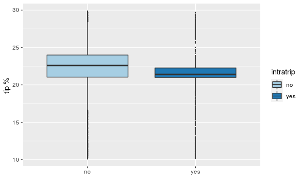

```r
## tip percentage
tip  <-  data[,c(11,14,28)]
tip$tipPer <- tip[,2]/tip[,1]*100
ggplot(tip, aes(x=intratrip,y=tipPer)) +
    labs(x=" ", y="tip % ")+
    geom_boxplot(aes(fill=intratrip),outlier.size = 0.1)+ scale_fill_brewer(palette="Paired")
```

The *median tip %* is lower for the intra-borough trips although as seen in previous figure the tip amount is largest.

#### tip % and day-night time

We can also evaluate if the tip % changes with the time the taxi is picked up. It doesn’t seem to be important differences.

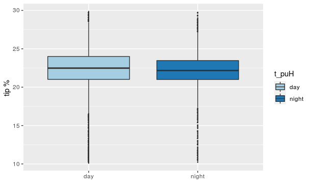

```r
## tip percentage
tip  <-  data[,c(11,14,25)]
tip$tipPer <- tip[,2]/tip[,1]*100
ggplot(tip, aes(x=t_puH,y=tipPer)) +
  labs(x=" ", y="tip % ")+
    geom_boxplot(aes(fill=t_puH),outlier.size = 0.1)+ scale_fill_brewer(palette="Paired")
```

```r
NA
```